# Analysis of finger/symbol experiment

Alexander D Forrence

September 28, 2015

```r
setwd("C:/Users/aforr_000/Desktop/lab-materials/force-analysis")


library(arm)
library(boot)
library(dplyr)
library(ggplot2)
library(nlme)
library(psyphy)
library(zoo)

blks <- list()
blknames <- list.files('csvfiles')
i <- 1
for (file in blknames) {
    blks[[i]] <- read.csv(paste0('csvfiles/',file), header = TRUE)
    i <- i + 1
}

#dplyr version
all_blks <- blks %>%
    bind_rows() %>%
    na.omit() %>%
    mutate(success = ifelse(targ_finger == press_finger, 1, 0)) %>%
    mutate(RT = t_press - t_stim) %>%
    filter(RT > 0) %>%
    add_rownames(var = 'ind') %>%
    mutate(ind = as.numeric(ind)) %>%
    arrange(RT) %>%
    mutate(cond = ifelse(t_stim == 0.75, 'prac', 'var'))
```

## Looking at the raw data

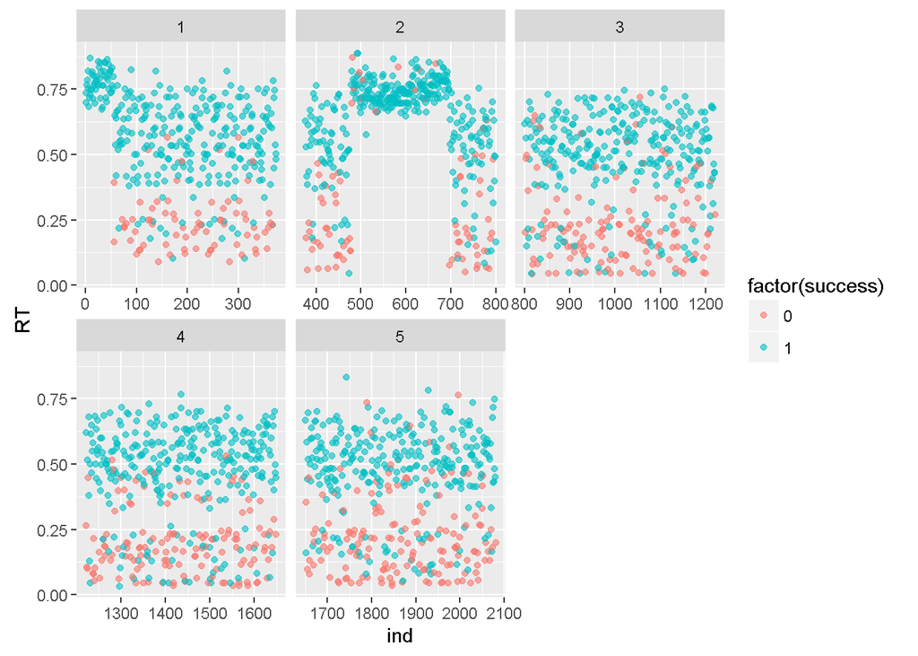

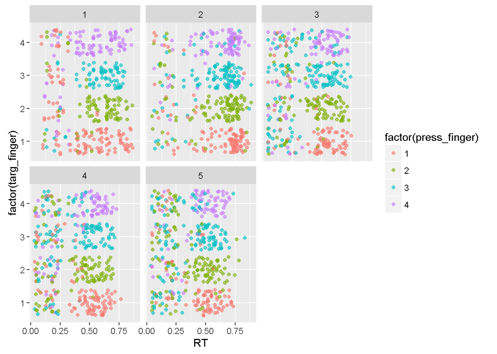

The `glm` function uses iteratively reweighted least squares (IRLS) to find a maximum likelihood solution.

```r
df <- filter(all_blks, cond == "var" & day > 1)
df_roll <- data.frame(roll_succ = rollmean(df$success, 70),
                      roll_rt = rollmean(df$RT, 70))
m0 <- glm(success ~ RT,
          data = df,
          family = binomial(psyphy::mafc.probit(4)))
m2 <- update(m0, . ~ 0 + RT * factor(day))
```

For some reason, profiling the likelihood doesn’t work properly. Maybe `profile.glm` from MASS doesn’t deal with “custom” link functions properly?

```r
summary(m2)
```

```
##
## Call:
## glm(formula = success ~ RT + factor(day) + RT:factor(day) - 1,
##     family = binomial(psyphy::mafc.probit(4)), data = df)
##
## Deviance Residuals:
##     Min       1Q   Median       3Q      Max
## -3.4349  -0.7731   0.2156   0.5873   1.6651
##
## Coefficients:
##                 Estimate Std. Error z value Pr(>|z|)
## RT                7.4283     1.4185   5.237 1.64e-07 ***
## factor(day)2     -2.7975     0.6790  -4.120 3.79e-05 ***
## factor(day)3     -2.6422     0.4395  -6.012 1.83e-09 ***
## factor(day)4     -5.0811     1.0672  -4.761 1.92e-06 ***
## factor(day)5     -2.6443     0.4345  -6.086 1.16e-09 ***
## RT:factor(day)3  -0.4354     1.6873  -0.258   0.7964
## RT:factor(day)4   5.6064     2.7468   2.041   0.0412 *
## RT:factor(day)5  -0.4635     1.6918  -0.274   0.7841
## ---
## Signif. codes:  0 '***' 0.001 '**' 0.01 '*' 0.05 '.' 0.1 ' ' 1
##
## (Dispersion parameter for binomial family taken to be 1)
##
##     Null deviance: 1902.5  on 1487  degrees of freedom
## Residual deviance: 1211.2  on 1479  degrees of freedom
## AIC: 1227.2
##
## Number of Fisher Scoring iterations: 18
```

RT on the x axis, P(success) on the y, fit cumulative gaussian

TODO: fit cumulative gaussian w/ boundaries (via mle2 in bbmle?)

## Examining the effect of days (could we do it block-by-block?)

Below are the “raw” data, along with the success plotted by reaction time.

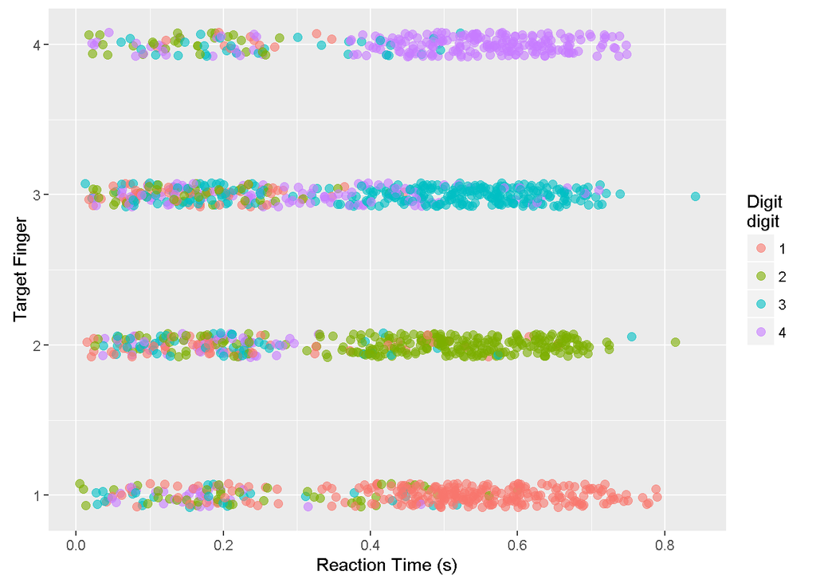

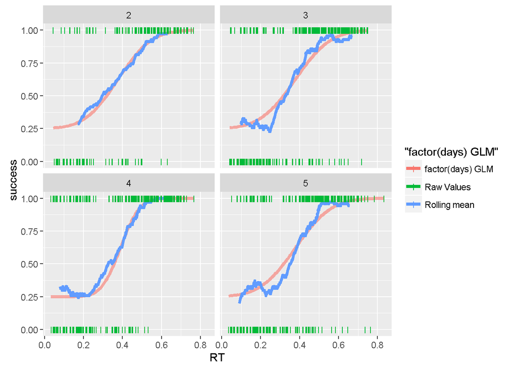

## Autocorrelation in the response?

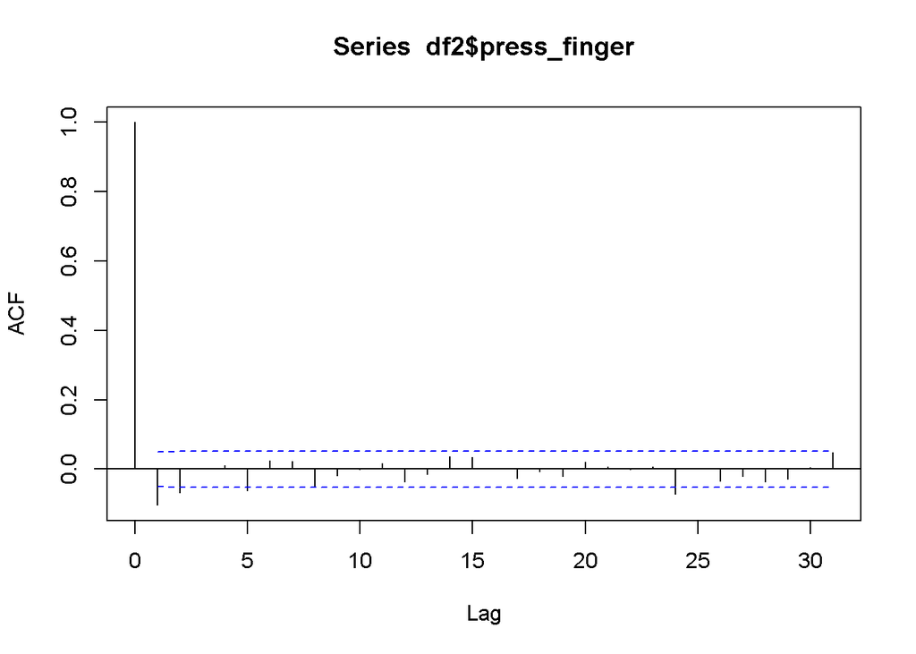

But there doesn’t seem to be much in the response residuals of the model (maybe due to the lack of data?)

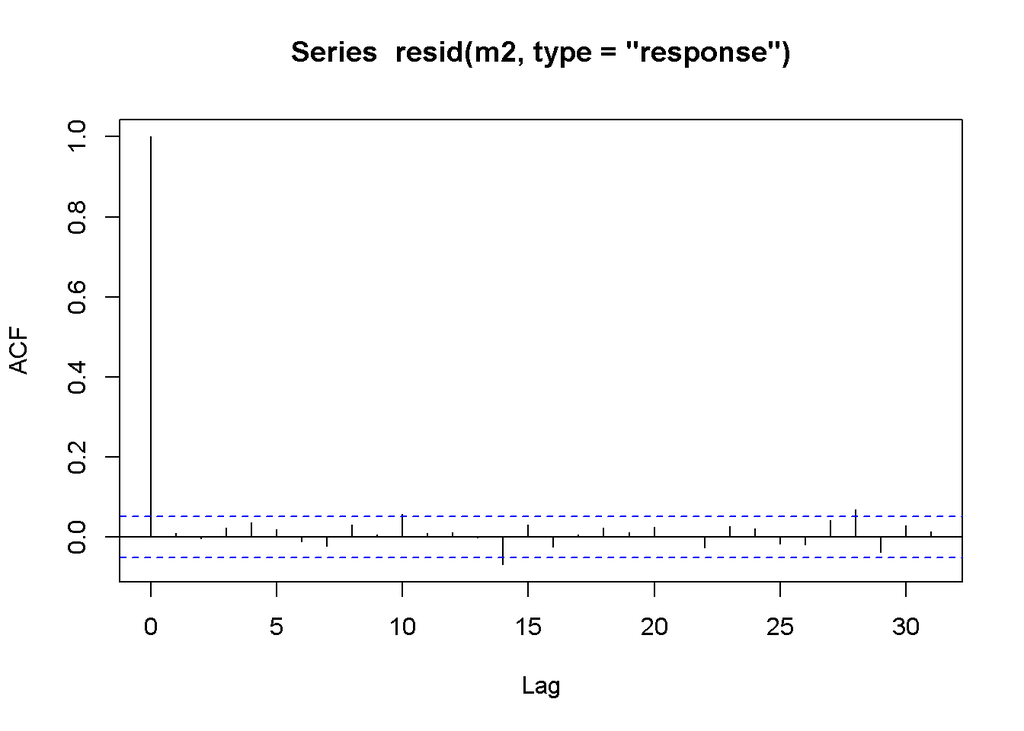

## Bootstrapping the midpoint

```r
glmfit <- function(data,indices) {
    fit <- glm(success ~ 0 + RT * factor(day),
               data = data[indices,],
               family = binomial(psyphy::mafc.probit(4)))
    temp <- coef(fit)
    # -b0/b1 for each day
    b <- c(0, 0, 0, 0)
    b[1] <- -temp[2] / temp[1]
    b[2] <- -temp[3] / (temp[1] + temp[6])
    b[3] <- -temp[4] / (temp[1] + temp[7])
    b[4] <- -temp[5] / (temp[1] + temp[8])
    return(b)
}

set.seed(1)

bb <- boot(data = df, statistic = glmfit, R = 2000)

boots <- t(sapply(X = 1:4,
                  FUN = function(x) boot.ci(bb, index = x, type = "perc")$percent))
boots <- data.frame(day = 2:5, orig = bb$t0,
                    lowci = boots[,4], hici = boots[,5])
boots
```

```
##   day      orig     lowci      hici
## 1   2 0.3765972 0.3232739 0.4320676
## 2   3 0.3778368 0.3452068 0.4089281
## 3   4 0.3898094 0.3540760 0.4161036
## 4   5 0.3796630 0.3465699 0.4234876
```

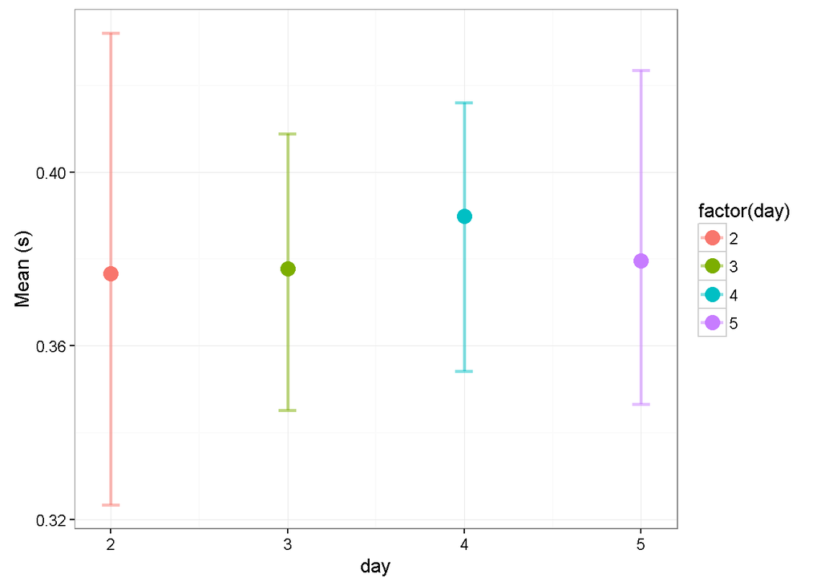

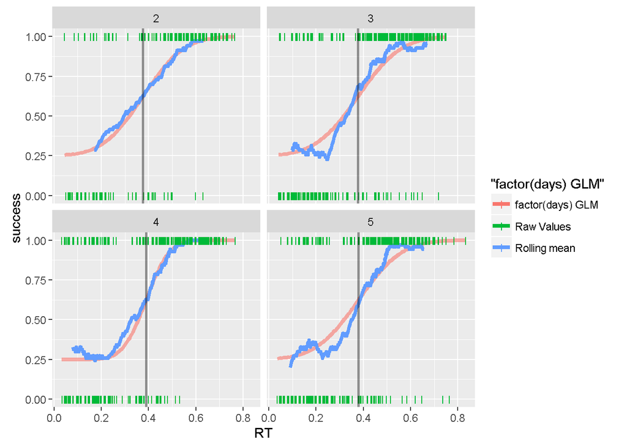

Using `stats::nls()`, which will give us something that looks more similar to the maximum likelihood:

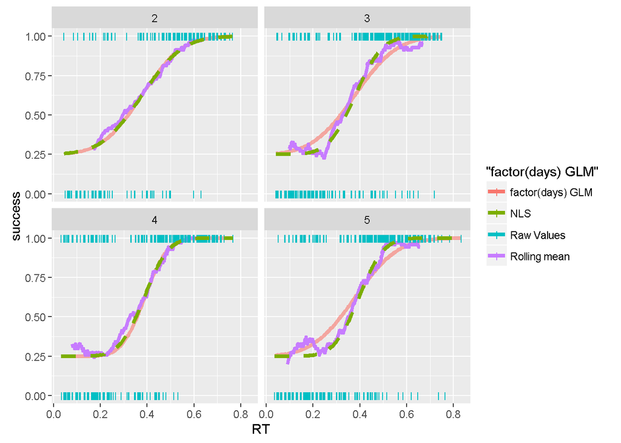

```r
df <- df %>% arrange(day, RT)

coefs <- list(mean = .4, sd = .1)
mods <- nlsList(success ~ 1/4 + (1 - 1/4) * pnorm(RT, mean, sd)| day,
         data = df,
         start = coefs)


df <- df %>%
    arrange(day, RT) %>%
    mutate(prednls = c(predict(mods, df)))

ggplot(data = df, aes(x = RT, y = success)) +
    geom_line(aes(y = resp2,
                  colour = "factor(days) GLM"),
              size = 1.5, alpha = 0.6) +
    geom_line(data = df_roll,
              aes(RT, success,
                  colour = "Rolling mean"),
              size = 1.5) +
    geom_point(aes(colour = "Raw Values"),
               size = 2, shape = 124) +
    geom_line(data = df,
              aes(x = RT, y = prednls, color = "NLS"),
              size = 1.5, linetype = "dashed")+
    facet_wrap(~day)
```

Which gives pretty similar answers to the `glm`.

```
## Call:
##   Model: success ~ 1/4 + (1 - 1/4) * pnorm(RT, mean, sd) | day
##    Data: df
##
## Coefficients:
##    mean
##    Estimate Std. Error  t value      Pr(>|t|)
## 2 0.3773012 0.02211343 17.06208  3.706065e-41
## 3 0.3800249 0.01400391 27.13706  6.156830e-94
## 4 0.3872467 0.01278112 30.29834 1.699008e-112
## 5 0.3957985 0.01217395 32.51193 2.502856e-114
##    sd
##     Estimate Std. Error  t value     Pr(>|t|)
## 2 0.13659367 0.02787767 4.899752 1.940483e-06
## 3 0.09064395 0.01703447 5.321209 1.845353e-07
## 4 0.08075030 0.01735189 4.653690 2.122901e-06
## 5 0.08321481 0.01629842 5.105697 9.759713e-07
##
## Residual standard error: 0.358409 on 1479 degrees of freedom
```

And profile confidence intervals on the mean:

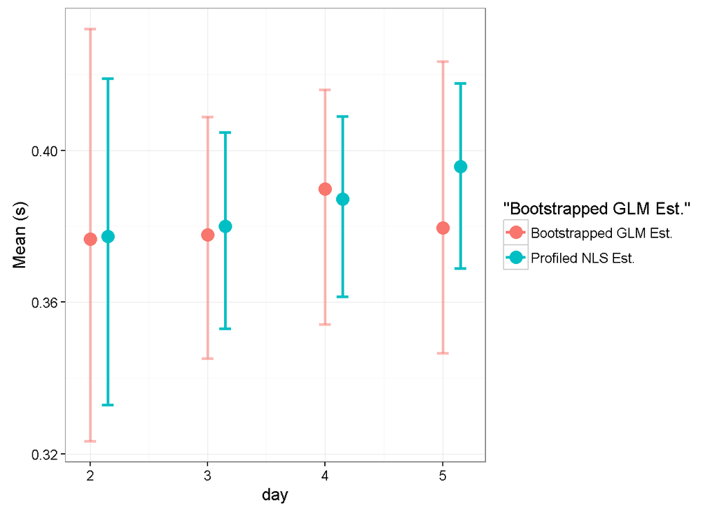

I also didn’t work out the equivalent of `sd` in the bootstrapped version, but the profile nls can be found below.

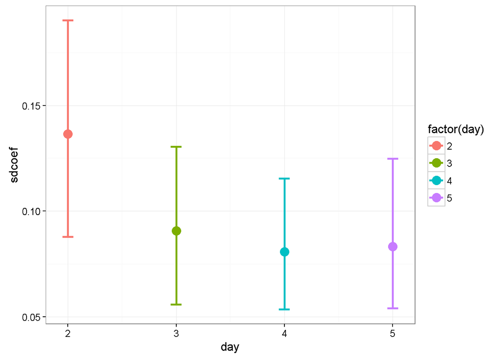

It looks like Michael leveled out (more or less) by day 3 - 4.